# NNF Data Science & AI Grant Landscape

An independent analysis of the **Novo Nordisk Foundation’s** data science and AI grant portfolio (2017–2024), built on open data from the [Danish Research Portal](https://forskningsportal.dk).

This project maps how NNF’s investment in data science and AI has evolved over time, which research domains and institutions receive the most DS/AI funding, how NNF compares to peer Danish funders, and what the language of funded grant abstracts reveals about shifting research priorities.

**Built by [Hugo Fitipaldi](https://linkedin.com/in/hugofitipaldi)** — biostatistician and data scientist at Novonesis, PhD in Genetic Epidemiology from Lund University.

## Live App

An interactive Shiny dashboard is available at:

**hugofitipaldi.shinyapps.io/nnf-grant-analysis**

## Data Source

Data was downloaded from the [Danish Research Portal](https://forskningsportal.dk) (forskningsportal.dk), which provides open access to grant metadata from major Danish research funders including NNF, the Independent Research Fund Denmark, the Carlsberg Foundation, the Lundbeck Foundation, and others.

The dataset covers 12,133 grants across six Danish funders (2016–2024). Analysis is restricted to the 3,642 NNF grants unless stated otherwise.

## Key Findings

### 1. NNF’s data science investment has accelerated sharply

NNF funded zero data science or AI grants in 2017. By 2024, 10.2% of all annual grants contained a significant DS/AI component — and the average DS/AI grant size more than doubled from DKK 2.6M to 5.5M. This is not just more grants: it is a strategic shift towards larger, longer-horizon data science investments.

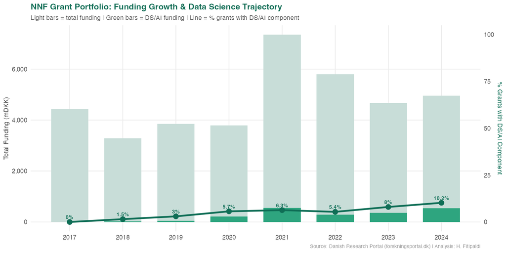

Portfolio trend

Health Sciences dominates NNF’s overall portfolio (64% of grants), but in data science specifically, Natural Sciences receives comparable funding in absolute terms despite fewer grants — reflecting larger individual award sizes. Agriculture & Veterinary Sciences, though small in grant count, has grown steadily since 2021.

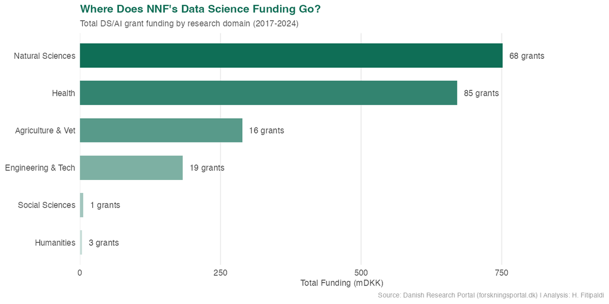

DS funding by domain

### 3. NNF shows the steepest DS/AI growth trajectory among large Danish funders

Villum Foundation leads in DS/AI intensity (11.5%) but shows high year-to-year volatility driven by its technical sciences focus. NNF started from 0% in 2017 and has shown the most consistent acceleration, reaching 10.2% in 2024. In absolute terms, NNF funds four times more data science than any other Danish funder — DKK 2 billion over the study period.

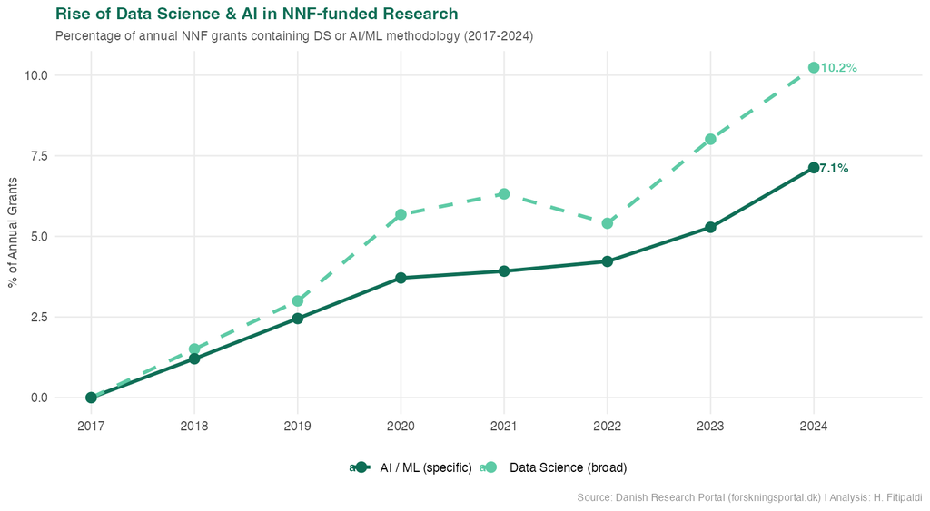

### 4. The sustainability pivot is visible in the language of funded grants

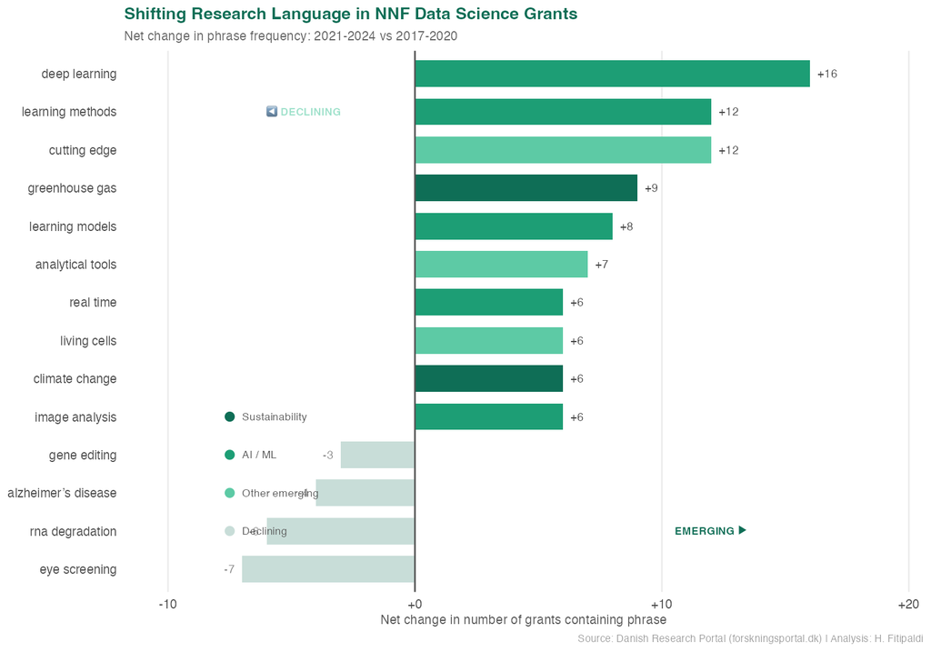

Diverging bar

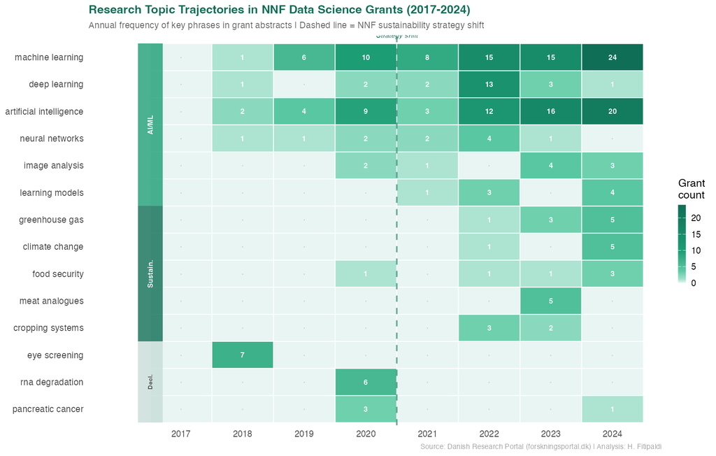

Bigram heatmap

### 5. DS/AI grants run longer than the portfolio average

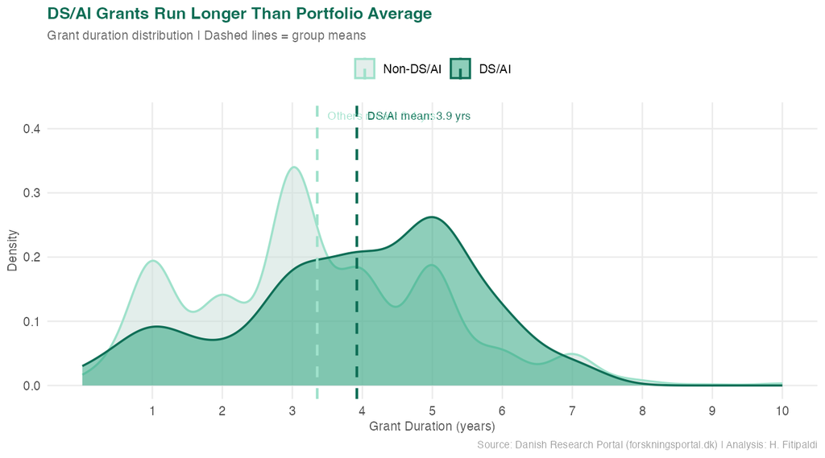

Duration distribution

## Shiny App

The interactive dashboard is built with R Shiny and `shinydashboard`. It has seven tabs:

| Tab | Contents |
| --- | --- |
| **Portfolio Overview** | Funding growth trend (interactive) + domain stacked area chart. Four summary value boxes. |
| **Data Science & AI** | AI/ML growth curve, DS funding by domain, top 15 institutions by funding and DS intensity (interactive). |
| **NNF vs Danish Funders** | DS/AI trajectory comparison across all six Danish funders, with NNF highlighted. Summary funding table. |
| **Geographic Reach** | Top 20 countries by NNF funding with grant count and DS/AI share (interactive). |
| **Research Topics** | Diverging bar chart (emerging vs declining phrases), bigram heatmap by year, and interactive word co-occurrence network. |
| **Grant Dynamics** | Open competition analysis, grant duration distributions by DS/AI flag and research domain. |
| **Explore Grants** | Searchable, filterable table of all NNF DS/AI grants with abstract previews. Filter by year, domain, and instrument. |

### Running locally

```r
# Install dependencies
install.packages(c(
  "shiny", "shinydashboard", "dplyr", "tidyr", "ggplot2",
  "plotly", "stringr", "rio", "scales", "forcats", "tidytext",
  "visNetwork", "igraph", "DT", "countrycode", "lubridate"
))

# Place grants-export-1.xlsx in the same directory as the app
shiny::runApp("nnf_app_final.R")
```

### Data

The source data (`grants-export-1.xlsx`) is not versioned in this repository as it is publicly available and can be downloaded directly from the [Danish Research Portal](https://forskningsportal.dk) by filtering for Danish funders and exporting to Excel.

## DS/AI Classification

Grants are classified as containing a data science or AI component using keyword matching on grant titles and abstracts. The classifier uses two tiers:

**Broad DS/AI** — includes machine learning, deep learning, artificial intelligence, neural networks, NLP, data science, predictive modelling, Bayesian methods, bioinformatics, computer vision, and related terms.

**AI/ML specific** — a stricter subset covering machine learning, deep learning, neural networks, generative AI, transformers, convolutional networks, foundation models, and large language models.

Classification is conservative by design — grants are only flagged when explicit methodology terms appear in the text, not based on domain keywords alone.

## Methods

All analysis is conducted in R. Key packages: `tidytext` for text mining and bigram analysis, `visNetwork` and `igraph` for the word co-occurrence network, `ggplot2` and `plotly` for visualisation, `shinydashboard` for the interactive app.

## Contact

Hugo Fitipaldi — hugofitipaldi@gmail.com

[LinkedIn](https://linkedin.com/in/hugofitipaldi) · [GitHub](https://github.com/hugofitipaldi)